# Risk Factor Analysis

## Outcome Variable

**Outcome Variable:** stunted

## Predictor Variables

**Intervention Variable:** fage

**Adjustment Set:**

- arm
- W_mage
- meducyrs
- feducyrs
- W_mhtcm
- W_mwtkg
- W_mbmi
- W_fhtcm
- single
- brthmon
- delta_W_mage
- delta_meducyrs
- delta_feducyrs
- delta_W_mhtcm
- delta_W_mwtkg
- delta_W_mbmi
- delta_W_fhtcm
- delta_single
- delta_brthmon

## Stratifying Variables

The analysis was stratified on these variable(s):

- agecat
- studyid
- country

## Data Summary

| agecat | studyid | country | fage | stunted | n_cell | n |
| --- | --- | --- | --- | --- | --- | --- |
| Birth | ki0047075b-MAL-ED | BANGLADESH | >=38 | 0 | 56 | 145 |
| Birth | ki0047075b-MAL-ED | BANGLADESH | >=38 | 1 | 11 | 145 |
| Birth | ki0047075b-MAL-ED | BANGLADESH | <32 | 0 | 24 | 145 |
| Birth | ki0047075b-MAL-ED | BANGLADESH | <32 | 1 | 3 | 145 |
| Birth | ki0047075b-MAL-ED | BANGLADESH | [32-38) | 0 | 45 | 145 |
| Birth | ki0047075b-MAL-ED | BANGLADESH | [32-38) | 1 | 6 | 145 |
| Birth | ki0047075b-MAL-ED | BRAZIL | >=38 | 0 | 23 | 68 |
| Birth | ki0047075b-MAL-ED | BRAZIL | >=38 | 1 | 4 | 68 |
| Birth | ki0047075b-MAL-ED | BRAZIL | <32 | 0 | 15 | 68 |
| Birth | ki0047075b-MAL-ED | BRAZIL | <32 | 1 | 1 | 68 |
| Birth | ki0047075b-MAL-ED | BRAZIL | [32-38) | 0 | 23 | 68 |
| Birth | ki0047075b-MAL-ED | BRAZIL | [32-38) | 1 | 2 | 68 |
| Birth | ki0047075b-MAL-ED | INDIA | >=38 | 0 | 24 | 131 |
| Birth | ki0047075b-MAL-ED | INDIA | >=38 | 1 | 3 | 131 |
| Birth | ki0047075b-MAL-ED | INDIA | <32 | 0 | 38 | 131 |
| Birth | ki0047075b-MAL-ED | INDIA | <32 | 1 | 6 | 131 |
| Birth | ki0047075b-MAL-ED | INDIA | [32-38) | 0 | 49 | 131 |
| Birth | ki0047075b-MAL-ED | INDIA | [32-38) | 1 | 11 | 131 |
| Birth | ki0047075b-MAL-ED | NEPAL | >=38 | 0 | 12 | 61 |
| Birth | ki0047075b-MAL-ED | NEPAL | >=38 | 1 | 1 | 61 |
| Birth | ki0047075b-MAL-ED | NEPAL | <32 | 0 | 9 | 61 |
| Birth | ki0047075b-MAL-ED | NEPAL | <32 | 1 | 0 | 61 |
| Birth | ki0047075b-MAL-ED | NEPAL | [32-38) | 0 | 35 | 61 |
| Birth | ki0047075b-MAL-ED | NEPAL | [32-38) | 1 | 4 | 61 |
| Birth | ki0047075b-MAL-ED | PERU | >=38 | 0 | 27 | 80 |
| Birth | ki0047075b-MAL-ED | PERU | >=38 | 1 | 0 | 80 |
| Birth | ki0047075b-MAL-ED | PERU | <32 | 0 | 22 | 80 |
| Birth | ki0047075b-MAL-ED | PERU | <32 | 1 | 5 | 80 |
| Birth | ki0047075b-MAL-ED | PERU | [32-38) | 0 | 21 | 80 |
| Birth | ki0047075b-MAL-ED | PERU | [32-38) | 1 | 5 | 80 |

[output cut: 180 more lines]

The following strata were considered:

- agecat: 24 months, studyid: ki0047075b-MAL-ED, country: BANGLADESH
- agecat: 24 months, studyid: ki0047075b-MAL-ED, country: BRAZIL
- agecat: 24 months, studyid: ki0047075b-MAL-ED, country: INDIA
- agecat: 24 months, studyid: ki0047075b-MAL-ED, country: NEPAL
- agecat: 24 months, studyid: ki0047075b-MAL-ED, country: PERU
- agecat: 24 months, studyid: ki0047075b-MAL-ED, country: SOUTH AFRICA
- agecat: 24 months, studyid: ki0047075b-MAL-ED, country: TANZANIA, UNITED REPUBLIC OF
- agecat: 24 months, studyid: ki1119695-PROBIT, country: BELARUS
- agecat: 24 months, studyid: ki1135781-COHORTS, country: GUATEMALA
- agecat: 24 months, studyid: ki1135781-COHORTS, country: PHILIPPINES
- agecat: 24 months, studyid: ki1148112-LCNI-5, country: MALAWI
- agecat: 6 months, studyid: ki0047075b-MAL-ED, country: BANGLADESH
- agecat: 6 months, studyid: ki0047075b-MAL-ED, country: BRAZIL
- agecat: 6 months, studyid: ki0047075b-MAL-ED, country: INDIA
- agecat: 6 months, studyid: ki0047075b-MAL-ED, country: NEPAL
- agecat: 6 months, studyid: ki0047075b-MAL-ED, country: PERU
- agecat: 6 months, studyid: ki0047075b-MAL-ED, country: SOUTH AFRICA
- agecat: 6 months, studyid: ki0047075b-MAL-ED, country: TANZANIA, UNITED REPUBLIC OF
- agecat: 6 months, studyid: ki1000304b-SAS-CompFeed, country: INDIA
- agecat: 6 months, studyid: ki1000304b-SAS-FoodSuppl, country: INDIA
- agecat: 6 months, studyid: ki1119695-PROBIT, country: BELARUS
- agecat: 6 months, studyid: ki1135781-COHORTS, country: GUATEMALA
- agecat: 6 months, studyid: ki1135781-COHORTS, country: PHILIPPINES
- agecat: 6 months, studyid: ki1148112-LCNI-5, country: MALAWI
- agecat: Birth, studyid: ki0047075b-MAL-ED, country: BANGLADESH
- agecat: Birth, studyid: ki0047075b-MAL-ED, country: BRAZIL
- agecat: Birth, studyid: ki0047075b-MAL-ED, country: INDIA
- agecat: Birth, studyid: ki0047075b-MAL-ED, country: NEPAL
- agecat: Birth, studyid: ki0047075b-MAL-ED, country: PERU
- agecat: Birth, studyid: ki0047075b-MAL-ED, country: SOUTH AFRICA
- agecat: Birth, studyid: ki0047075b-MAL-ED, country: TANZANIA, UNITED REPUBLIC OF
- agecat: Birth, studyid: ki1000304b-SAS-CompFeed, country: INDIA
- agecat: Birth, studyid: ki1119695-PROBIT, country: BELARUS
- agecat: Birth, studyid: ki1135781-COHORTS, country: GUATEMALA
- agecat: Birth, studyid: ki1135781-COHORTS, country: PHILIPPINES

### Dropped Strata

Some strata were dropped due to rare outcomes:

- agecat: Birth, studyid: ki0047075b-MAL-ED, country: BANGLADESH
- agecat: Birth, studyid: ki0047075b-MAL-ED, country: BRAZIL
- agecat: Birth, studyid: ki0047075b-MAL-ED, country: INDIA
- agecat: Birth, studyid: ki0047075b-MAL-ED, country: NEPAL
- agecat: Birth, studyid: ki0047075b-MAL-ED, country: PERU
- agecat: Birth, studyid: ki0047075b-MAL-ED, country: SOUTH AFRICA
- agecat: Birth, studyid: ki0047075b-MAL-ED, country: TANZANIA, UNITED REPUBLIC OF
- agecat: Birth, studyid: ki1000304b-SAS-CompFeed, country: INDIA
- agecat: Birth, studyid: ki1119695-PROBIT, country: BELARUS
- agecat: 6 months, studyid: ki0047075b-MAL-ED, country: BRAZIL
- agecat: 6 months, studyid: ki0047075b-MAL-ED, country: NEPAL
- agecat: 6 months, studyid: ki0047075b-MAL-ED, country: PERU
- agecat: 6 months, studyid: ki0047075b-MAL-ED, country: SOUTH AFRICA
- agecat: 24 months, studyid: ki0047075b-MAL-ED, country: BRAZIL
- agecat: 24 months, studyid: ki0047075b-MAL-ED, country: NEPAL
- agecat: 24 months, studyid: ki0047075b-MAL-ED, country: SOUTH AFRICA
- agecat: 24 months, studyid: ki0047075b-MAL-ED, country: TANZANIA, UNITED REPUBLIC OF
- agecat: 24 months, studyid: ki1148112-LCNI-5, country: MALAWI

## Methods Detail

We’re interested in the causal parameters $E[Y_a]$ for all values of $a \in \mathcal{A}$. These parameters represent the mean outcome if, possibly contrary to fact, we intervened to set all units to have $A=a$. Under the randomization and positivity assumptions, these are identified by the statistical parameters $\psi_a=E_W[E_{Y|A,W}(Y|A=a,W)]$. In addition, we’re interested in the mean of $Y$, $E[Y]$ under no intervention (the observed mean). We will estimate these parameters by using SuperLearner to fit the relevant likelihood factors – $E_{Y|A,W}(Y|A=a,W)$ and $p(A=a|W)$, and then updating our likelihood fit using a joint TMLE.

For unadjusted analyses ($W=\{\}$), initial likelihoods were estimated using Lrnr_glm to estimate the simple $E(Y|A)$ and Lrnr_mean to estimate $p(A)$. For adjusted analyses, a small library containing Lrnr_glmnet, Lrnr_xgboost, and Lrnr_mean was used.

Having estimated these parameters, we will then use the delta method to estimate relative risks and attributable risks relative to a prespecified baseline level of $A$.

# Results Detail

## Results Plots

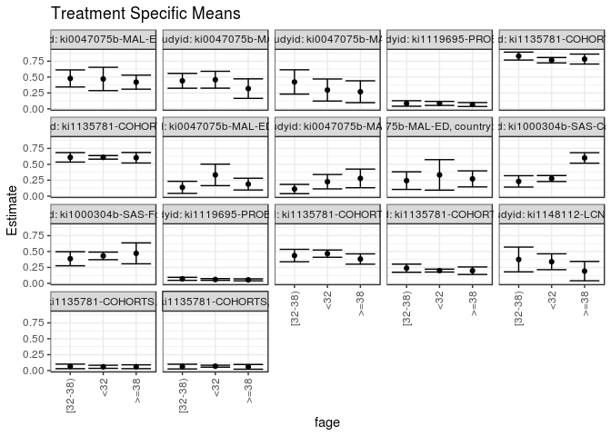

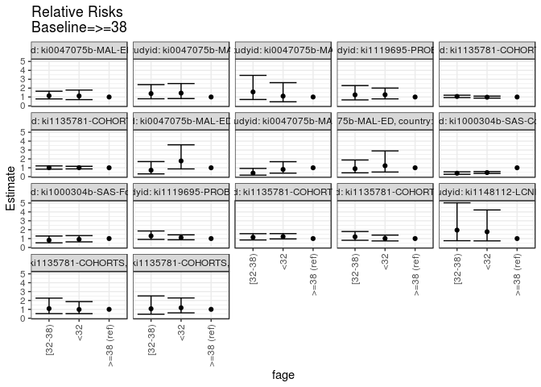

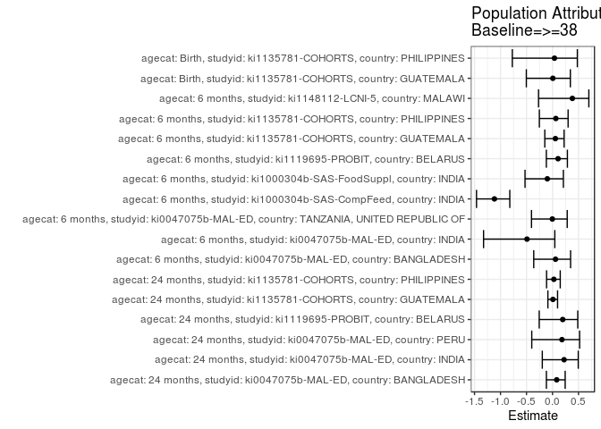

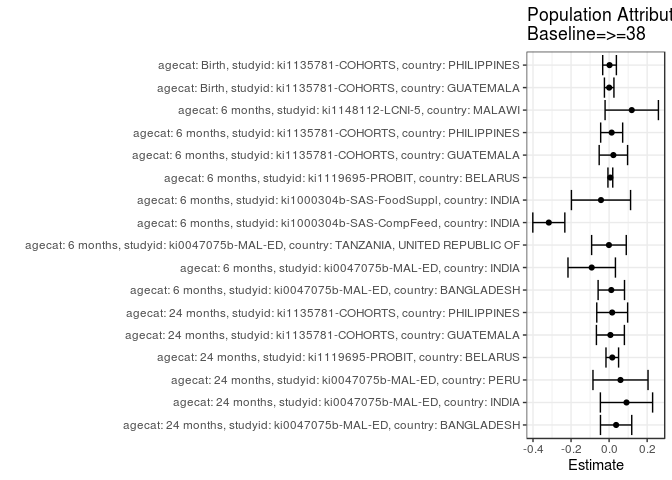

## Results Table

### Parameter: TSM

| agecat | studyid | country | intervention_level | baseline_level | estimate | ci_lower | ci_upper |
| --- | --- | --- | --- | --- | --- | --- | --- |
| Birth | ki1135781-COHORTS | GUATEMALA | >=38 | NA | 0.0603572 | 0.0305173 | 0.0901970 |
| Birth | ki1135781-COHORTS | GUATEMALA | <32 | NA | 0.0593939 | 0.0350196 | 0.0837682 |
| Birth | ki1135781-COHORTS | GUATEMALA | [32-38) | NA | 0.0654540 | 0.0298710 | 0.1010371 |
| Birth | ki1135781-COHORTS | PHILIPPINES | >=38 | NA | 0.0588355 | 0.0221010 | 0.0955699 |
| Birth | ki1135781-COHORTS | PHILIPPINES | <32 | NA | 0.0691154 | 0.0537019 | 0.0845289 |
| Birth | ki1135781-COHORTS | PHILIPPINES | [32-38) | NA | 0.0627508 | 0.0259866 | 0.0995150 |
| 6 months | ki0047075b-MAL-ED | BANGLADESH | >=38 | NA | 0.1884058 | 0.0958310 | 0.2809806 |
| 6 months | ki0047075b-MAL-ED | BANGLADESH | <32 | NA | 0.3333333 | 0.1640814 | 0.5025853 |
| 6 months | ki0047075b-MAL-ED | BANGLADESH | [32-38) | NA | 0.1372549 | 0.0424959 | 0.2320139 |
| 6 months | ki0047075b-MAL-ED | INDIA | >=38 | NA | 0.2777778 | 0.1310089 | 0.4245467 |
| 6 months | ki0047075b-MAL-ED | INDIA | <32 | NA | 0.2264151 | 0.1133913 | 0.3394389 |
| 6 months | ki0047075b-MAL-ED | INDIA | [32-38) | NA | 0.1111111 | 0.0382934 | 0.1839289 |
| 6 months | ki0047075b-MAL-ED | TANZANIA, UNITED REPUBLIC OF | >=38 | NA | 0.2708333 | 0.1444836 | 0.3971831 |
| 6 months | ki0047075b-MAL-ED | TANZANIA, UNITED REPUBLIC OF | <32 | NA | 0.3333333 | 0.0935723 | 0.5730944 |
| 6 months | ki0047075b-MAL-ED | TANZANIA, UNITED REPUBLIC OF | [32-38) | NA | 0.2432432 | 0.1043030 | 0.3821835 |
| 6 months | ki1000304b-SAS-CompFeed | INDIA | >=38 | NA | 0.6004140 | 0.5180813 | 0.6827468 |
| 6 months | ki1000304b-SAS-CompFeed | INDIA | <32 | NA | 0.2762405 | 0.2293615 | 0.3231195 |
| 6 months | ki1000304b-SAS-CompFeed | INDIA | [32-38) | NA | 0.2309835 | 0.1413696 | 0.3205974 |
| 6 months | ki1000304b-SAS-FoodSuppl | INDIA | >=38 | NA | 0.4715804 | 0.3072846 | 0.6358761 |
| 6 months | ki1000304b-SAS-FoodSuppl | INDIA | <32 | NA | 0.4315869 | 0.3717440 | 0.4914297 |
| 6 months | ki1000304b-SAS-FoodSuppl | INDIA | [32-38) | NA | 0.3866448 | 0.2762160 | 0.4970736 |
| 6 months | ki1119695-PROBIT | BELARUS | >=38 | NA | 0.0546568 | 0.0390924 | 0.0702212 |
| 6 months | ki1119695-PROBIT | BELARUS | <32 | NA | 0.0605199 | 0.0468454 | 0.0741943 |
| 6 months | ki1119695-PROBIT | BELARUS | [32-38) | NA | 0.0706934 | 0.0471599 | 0.0942270 |
| 6 months | ki1135781-COHORTS | GUATEMALA | >=38 | NA | 0.3822488 | 0.3015844 | 0.4629132 |
| 6 months | ki1135781-COHORTS | GUATEMALA | <32 | NA | 0.4671695 | 0.4100616 | 0.5242774 |
| 6 months | ki1135781-COHORTS | GUATEMALA | [32-38) | NA | 0.4368191 | 0.3391246 | 0.5345136 |
| 6 months | ki1135781-COHORTS | PHILIPPINES | >=38 | NA | 0.1984085 | 0.1392939 | 0.2575230 |
| 6 months | ki1135781-COHORTS | PHILIPPINES | <32 | NA | 0.2002702 | 0.1771989 | 0.2233415 |
| 6 months | ki1135781-COHORTS | PHILIPPINES | [32-38) | NA | 0.2379416 | 0.1742018 | 0.3016814 |
| 6 months | ki1148112-LCNI-5 | MALAWI | >=38 | NA | 0.1923077 | 0.0400985 | 0.3445169 |
| 6 months | ki1148112-LCNI-5 | MALAWI | <32 | NA | 0.3392857 | 0.2146903 | 0.4638811 |
| 6 months | ki1148112-LCNI-5 | MALAWI | [32-38) | NA | 0.3750000 | 0.1803939 | 0.5696061 |
| 24 months | ki0047075b-MAL-ED | BANGLADESH | >=38 | NA | 0.4201261 | 0.3096290 | 0.5306232 |
| 24 months | ki0047075b-MAL-ED | BANGLADESH | <32 | NA | 0.4702594 | 0.2869583 | 0.6535604 |
| 24 months | ki0047075b-MAL-ED | BANGLADESH | [32-38) | NA | 0.4783799 | 0.3441171 | 0.6126428 |
| 24 months | ki0047075b-MAL-ED | INDIA | >=38 | NA | 0.3185044 | 0.1648698 | 0.4721391 |
| 24 months | ki0047075b-MAL-ED | INDIA | <32 | NA | 0.4581094 | 0.3253927 | 0.5908261 |
| 24 months | ki0047075b-MAL-ED | INDIA | [32-38) | NA | 0.4410072 | 0.3243757 | 0.5576387 |
| 24 months | ki0047075b-MAL-ED | PERU | >=38 | NA | 0.2692308 | 0.0976454 | 0.4408161 |
| 24 months | ki0047075b-MAL-ED | PERU | <32 | NA | 0.2962963 | 0.1229596 | 0.4696330 |
| 24 months | ki0047075b-MAL-ED | PERU | [32-38) | NA | 0.4230769 | 0.2319613 | 0.6141926 |
| 24 months | ki1119695-PROBIT | BELARUS | >=38 | NA | 0.0682270 | 0.0372579 | 0.0991960 |
| 24 months | ki1119695-PROBIT | BELARUS | <32 | NA | 0.0858008 | 0.0540378 | 0.1175638 |
| 24 months | ki1119695-PROBIT | BELARUS | [32-38) | NA | 0.0847809 | 0.0415042 | 0.1280575 |
| 24 months | ki1135781-COHORTS | GUATEMALA | >=38 | NA | 0.7831850 | 0.7051664 | 0.8612035 |
| 24 months | ki1135781-COHORTS | GUATEMALA | <32 | NA | 0.7651576 | 0.7229885 | 0.8073268 |
| 24 months | ki1135781-COHORTS | GUATEMALA | [32-38) | NA | 0.8302114 | 0.7677061 | 0.8927168 |
| 24 months | ki1135781-COHORTS | PHILIPPINES | >=38 | NA | 0.6032907 | 0.5205617 | 0.6860197 |
| 24 months | ki1135781-COHORTS | PHILIPPINES | <32 | NA | 0.6091748 | 0.5811501 | 0.6371994 |
| 24 months | ki1135781-COHORTS | PHILIPPINES | [32-38) | NA | 0.6094522 | 0.5347793 | 0.6841251 |

### Parameter: E(Y)

| agecat | studyid | country | intervention_level | baseline_level | estimate | ci_lower | ci_upper |
| --- | --- | --- | --- | --- | --- | --- | --- |
| Birth | ki1135781-COHORTS | GUATEMALA | NA | NA | 0.0607533 | 0.0444233 | 0.0770834 |
| Birth | ki1135781-COHORTS | PHILIPPINES | NA | NA | 0.0611413 | 0.0524852 | 0.0697974 |
| 6 months | ki0047075b-MAL-ED | BANGLADESH | NA | NA | 0.2000000 | 0.1357734 | 0.2642266 |
| 6 months | ki0047075b-MAL-ED | INDIA | NA | NA | 0.1863354 | 0.1260019 | 0.2466689 |
| 6 months | ki0047075b-MAL-ED | TANZANIA, UNITED REPUBLIC OF | NA | NA | 0.2700000 | 0.1825472 | 0.3574528 |
| 6 months | ki1000304b-SAS-CompFeed | INDIA | NA | NA | 0.2835709 | 0.2656121 | 0.3015297 |
| 6 months | ki1000304b-SAS-FoodSuppl | INDIA | NA | NA | 0.4289474 | 0.3791199 | 0.4787748 |
| 6 months | ki1119695-PROBIT | BELARUS | NA | NA | 0.0611869 | 0.0477477 | 0.0746260 |
| 6 months | ki1135781-COHORTS | GUATEMALA | NA | NA | 0.4047363 | 0.3731561 | 0.4363165 |
| 6 months | ki1135781-COHORTS | PHILIPPINES | NA | NA | 0.2118902 | 0.1962516 | 0.2275288 |
| 6 months | ki1148112-LCNI-5 | MALAWI | NA | NA | 0.3113208 | 0.2227550 | 0.3998865 |
| 24 months | ki0047075b-MAL-ED | BANGLADESH | NA | NA | 0.4569536 | 0.3772355 | 0.5366718 |
| 24 months | ki0047075b-MAL-ED | INDIA | NA | NA | 0.4099379 | 0.3337307 | 0.4861451 |
| 24 months | ki0047075b-MAL-ED | PERU | NA | NA | 0.3291139 | 0.2248346 | 0.4333933 |
| 24 months | ki1119695-PROBIT | BELARUS | NA | NA | 0.0849322 | 0.0549995 | 0.1148649 |
| 24 months | ki1135781-COHORTS | GUATEMALA | NA | NA | 0.7900391 | 0.7650814 | 0.8149967 |
| 24 months | ki1135781-COHORTS | PHILIPPINES | NA | NA | 0.6195698 | 0.6000239 | 0.6391157 |

### Parameter: RR

| agecat | studyid | country | intervention_level | baseline_level | estimate | ci_lower | ci_upper |
| --- | --- | --- | --- | --- | --- | --- | --- |
| Birth | ki1135781-COHORTS | GUATEMALA | >=38 | >=38 | 1.0000000 | 1.0000000 | 1.0000000 |
| Birth | ki1135781-COHORTS | GUATEMALA | <32 | >=38 | 0.9840401 | 0.5174012 | 1.8715357 |
| Birth | ki1135781-COHORTS | GUATEMALA | [32-38) | >=38 | 1.0844446 | 0.5200684 | 2.2612798 |
| Birth | ki1135781-COHORTS | PHILIPPINES | >=38 | >=38 | 1.0000000 | 1.0000000 | 1.0000000 |
| Birth | ki1135781-COHORTS | PHILIPPINES | <32 | >=38 | 1.1747233 | 0.6054892 | 2.2791073 |
| Birth | ki1135781-COHORTS | PHILIPPINES | [32-38) | >=38 | 1.0665472 | 0.4528620 | 2.5118531 |
| 6 months | ki0047075b-MAL-ED | BANGLADESH | >=38 | >=38 | 1.0000000 | 1.0000000 | 1.0000000 |
| 6 months | ki0047075b-MAL-ED | BANGLADESH | <32 | >=38 | 1.7692308 | 0.8728158 | 3.5862980 |
| 6 months | ki0047075b-MAL-ED | BANGLADESH | [32-38) | >=38 | 0.7285068 | 0.3121888 | 1.7000037 |
| 6 months | ki0047075b-MAL-ED | INDIA | >=38 | >=38 | 1.0000000 | 1.0000000 | 1.0000000 |
| 6 months | ki0047075b-MAL-ED | INDIA | <32 | >=38 | 0.8150943 | 0.3940268 | 1.6861258 |
| 6 months | ki0047075b-MAL-ED | INDIA | [32-38) | >=38 | 0.4000000 | 0.1723694 | 0.9282392 |
| 6 months | ki0047075b-MAL-ED | TANZANIA, UNITED REPUBLIC OF | >=38 | >=38 | 1.0000000 | 1.0000000 | 1.0000000 |
| 6 months | ki0047075b-MAL-ED | TANZANIA, UNITED REPUBLIC OF | <32 | >=38 | 1.2307692 | 0.5222084 | 2.9007439 |
| 6 months | ki0047075b-MAL-ED | TANZANIA, UNITED REPUBLIC OF | [32-38) | >=38 | 0.8981289 | 0.4295810 | 1.8777263 |
| 6 months | ki1000304b-SAS-CompFeed | INDIA | >=38 | >=38 | 1.0000000 | 1.0000000 | 1.0000000 |
| 6 months | ki1000304b-SAS-CompFeed | INDIA | <32 | >=38 | 0.4600833 | 0.3684095 | 0.5745689 |
| 6 months | ki1000304b-SAS-CompFeed | INDIA | [32-38) | >=38 | 0.3847070 | 0.2700508 | 0.5480431 |
| 6 months | ki1000304b-SAS-FoodSuppl | INDIA | >=38 | >=38 | 1.0000000 | 1.0000000 | 1.0000000 |
| 6 months | ki1000304b-SAS-FoodSuppl | INDIA | <32 | >=38 | 0.9151926 | 0.6290761 | 1.3314407 |
| 6 months | ki1000304b-SAS-FoodSuppl | INDIA | [32-38) | >=38 | 0.8198917 | 0.5226171 | 1.2862618 |
| 6 months | ki1119695-PROBIT | BELARUS | >=38 | >=38 | 1.0000000 | 1.0000000 | 1.0000000 |
| 6 months | ki1119695-PROBIT | BELARUS | <32 | >=38 | 1.1072708 | 0.8636498 | 1.4196131 |
| 6 months | ki1119695-PROBIT | BELARUS | [32-38) | >=38 | 1.2934065 | 0.9029945 | 1.8526141 |
| 6 months | ki1135781-COHORTS | GUATEMALA | >=38 | >=38 | 1.0000000 | 1.0000000 | 1.0000000 |
| 6 months | ki1135781-COHORTS | GUATEMALA | <32 | >=38 | 1.2221607 | 0.9599465 | 1.5560001 |
| 6 months | ki1135781-COHORTS | GUATEMALA | [32-38) | >=38 | 1.1427611 | 0.8416168 | 1.5516600 |
| 6 months | ki1135781-COHORTS | PHILIPPINES | >=38 | >=38 | 1.0000000 | 1.0000000 | 1.0000000 |
| 6 months | ki1135781-COHORTS | PHILIPPINES | <32 | >=38 | 1.0093830 | 0.7336091 | 1.3888241 |
| 6 months | ki1135781-COHORTS | PHILIPPINES | [32-38) | >=38 | 1.1992511 | 0.8034287 | 1.7900819 |
| 6 months | ki1148112-LCNI-5 | MALAWI | >=38 | >=38 | 1.0000000 | 1.0000000 | 1.0000000 |
| 6 months | ki1148112-LCNI-5 | MALAWI | <32 | >=38 | 1.7642857 | 0.7372819 | 4.2218641 |
| 6 months | ki1148112-LCNI-5 | MALAWI | [32-38) | >=38 | 1.9500000 | 0.7568292 | 5.0242509 |
| 24 months | ki0047075b-MAL-ED | BANGLADESH | >=38 | >=38 | 1.0000000 | 1.0000000 | 1.0000000 |
| 24 months | ki0047075b-MAL-ED | BANGLADESH | <32 | >=38 | 1.1193291 | 0.7029258 | 1.7824040 |
| 24 months | ki0047075b-MAL-ED | BANGLADESH | [32-38) | >=38 | 1.1386580 | 0.7845548 | 1.6525833 |
| 24 months | ki0047075b-MAL-ED | INDIA | >=38 | >=38 | 1.0000000 | 1.0000000 | 1.0000000 |
| 24 months | ki0047075b-MAL-ED | INDIA | <32 | >=38 | 1.4383141 | 0.8234440 | 2.5123109 |
| 24 months | ki0047075b-MAL-ED | INDIA | [32-38) | >=38 | 1.3846186 | 0.8000267 | 2.3963810 |
| 24 months | ki0047075b-MAL-ED | PERU | >=38 | >=38 | 1.0000000 | 1.0000000 | 1.0000000 |
| 24 months | ki0047075b-MAL-ED | PERU | <32 | >=38 | 1.1005291 | 0.4633297 | 2.6140444 |
| 24 months | ki0047075b-MAL-ED | PERU | [32-38) | >=38 | 1.5714286 | 0.7195080 | 3.4320507 |
| 24 months | ki1119695-PROBIT | BELARUS | >=38 | >=38 | 1.0000000 | 1.0000000 | 1.0000000 |
| 24 months | ki1119695-PROBIT | BELARUS | <32 | >=38 | 1.2575790 | 0.7880395 | 2.0068852 |
| 24 months | ki1119695-PROBIT | BELARUS | [32-38) | >=38 | 1.2426302 | 0.6748976 | 2.2879468 |
| 24 months | ki1135781-COHORTS | GUATEMALA | >=38 | >=38 | 1.0000000 | 1.0000000 | 1.0000000 |
| 24 months | ki1135781-COHORTS | GUATEMALA | <32 | >=38 | 0.9769820 | 0.8723650 | 1.0941451 |
| 24 months | ki1135781-COHORTS | GUATEMALA | [32-38) | >=38 | 1.0600452 | 0.9358449 | 1.2007286 |
| 24 months | ki1135781-COHORTS | PHILIPPINES | >=38 | >=38 | 1.0000000 | 1.0000000 | 1.0000000 |
| 24 months | ki1135781-COHORTS | PHILIPPINES | <32 | >=38 | 1.0097533 | 0.8741862 | 1.1663438 |
| 24 months | ki1135781-COHORTS | PHILIPPINES | [32-38) | >=38 | 1.0102131 | 0.8407720 | 1.2138018 |

### Parameter: PAR

| agecat | studyid | country | intervention_level | baseline_level | estimate | ci_lower | ci_upper |
| --- | --- | --- | --- | --- | --- | --- | --- |
| Birth | ki1135781-COHORTS | GUATEMALA | >=38 | NA | 0.0003962 | -0.0246053 | 0.0253976 |
| Birth | ki1135781-COHORTS | PHILIPPINES | >=38 | NA | 0.0023058 | -0.0336651 | 0.0382768 |
| 6 months | ki0047075b-MAL-ED | BANGLADESH | >=38 | NA | 0.0115942 | -0.0577647 | 0.0809531 |
| 6 months | ki0047075b-MAL-ED | INDIA | >=38 | NA | -0.0914424 | -0.2161338 | 0.0332490 |
| 6 months | ki0047075b-MAL-ED | TANZANIA, UNITED REPUBLIC OF | >=38 | NA | -0.0008333 | -0.0918639 | 0.0901972 |
| 6 months | ki1000304b-SAS-CompFeed | INDIA | >=38 | NA | -0.3168431 | -0.4009721 | -0.2327141 |
| 6 months | ki1000304b-SAS-FoodSuppl | INDIA | >=38 | NA | -0.0426330 | -0.1980687 | 0.1128027 |
| 6 months | ki1119695-PROBIT | BELARUS | >=38 | NA | 0.0065301 | -0.0060977 | 0.0191579 |
| 6 months | ki1135781-COHORTS | GUATEMALA | >=38 | NA | 0.0224875 | -0.0521541 | 0.0971291 |
| 6 months | ki1135781-COHORTS | PHILIPPINES | >=38 | NA | 0.0134818 | -0.0443216 | 0.0712851 |
| 6 months | ki1148112-LCNI-5 | MALAWI | >=38 | NA | 0.1190131 | -0.0211521 | 0.2591783 |
| 24 months | ki0047075b-MAL-ED | BANGLADESH | >=38 | NA | 0.0368276 | -0.0453342 | 0.1189894 |
| 24 months | ki0047075b-MAL-ED | INDIA | >=38 | NA | 0.0914334 | -0.0458293 | 0.2286962 |
| 24 months | ki0047075b-MAL-ED | PERU | >=38 | NA | 0.0598832 | -0.0848113 | 0.2045776 |
| 24 months | ki1119695-PROBIT | BELARUS | >=38 | NA | 0.0167053 | -0.0164139 | 0.0498244 |
| 24 months | ki1135781-COHORTS | GUATEMALA | >=38 | NA | 0.0068541 | -0.0666441 | 0.0803523 |
| 24 months | ki1135781-COHORTS | PHILIPPINES | >=38 | NA | 0.0162791 | -0.0648709 | 0.0974291 |

### Parameter: PAF

| agecat | studyid | country | intervention_level | baseline_level | estimate | ci_lower | ci_upper |
| --- | --- | --- | --- | --- | --- | --- | --- |
| Birth | ki1135781-COHORTS | GUATEMALA | >=38 | NA | 0.0065209 | -0.5033321 | 0.3434580 |
| Birth | ki1135781-COHORTS | PHILIPPINES | >=38 | NA | 0.0377132 | -0.7732091 | 0.4777853 |
| 6 months | ki0047075b-MAL-ED | BANGLADESH | >=38 | NA | 0.0579710 | -0.3608861 | 0.3479112 |
| 6 months | ki0047075b-MAL-ED | INDIA | >=38 | NA | -0.4907407 | -1.3259527 | 0.0445601 |
| 6 months | ki0047075b-MAL-ED | TANZANIA, UNITED REPUBLIC OF | >=38 | NA | -0.0030864 | -0.4038159 | 0.2832519 |
| 6 months | ki1000304b-SAS-CompFeed | INDIA | >=38 | NA | -1.1173331 | -1.4614344 | -0.8213362 |
| 6 months | ki1000304b-SAS-FoodSuppl | INDIA | >=38 | NA | -0.0993898 | -0.5285068 | 0.2092558 |
| 6 months | ki1119695-PROBIT | BELARUS | >=38 | NA | 0.1067235 | -0.1185400 | 0.2866211 |
| 6 months | ki1135781-COHORTS | GUATEMALA | >=38 | NA | 0.0555608 | -0.1480896 | 0.2230873 |
| 6 months | ki1135781-COHORTS | PHILIPPINES | >=38 | NA | 0.0636261 | -0.2528042 | 0.3001332 |
| 6 months | ki1148112-LCNI-5 | MALAWI | >=38 | NA | 0.3822844 | -0.2683064 | 0.6991479 |
| 24 months | ki0047075b-MAL-ED | BANGLADESH | >=38 | NA | 0.0805936 | -0.1174944 | 0.2435684 |
| 24 months | ki0047075b-MAL-ED | INDIA | >=38 | NA | 0.2230422 | -0.1962948 | 0.4953891 |
| 24 months | ki0047075b-MAL-ED | PERU | >=38 | NA | 0.1819527 | -0.3989032 | 0.5216242 |
| 24 months | ki1119695-PROBIT | BELARUS | >=38 | NA | 0.1966892 | -0.2554997 | 0.4860148 |
| 24 months | ki1135781-COHORTS | GUATEMALA | >=38 | NA | 0.0086756 | -0.0888661 | 0.0974794 |
| 24 months | ki1135781-COHORTS | PHILIPPINES | >=38 | NA | 0.0262748 | -0.1138871 | 0.1488000 |